# Comparing Bob Hall’s AR(1) light-varying model with streamMetabolizer

- Show All Code
- Hide All Code
- View Source

metab_pi_ar_light_2.stan vs. streamMetabolizer’s AR(1), light-varying process-error model

Author

Connor Brown

Published

July 12, 2026

This document is the literate version of `compare_bob_ar_light.R`. It fits Bob Hall’s `metab_pi_ar_light_2.stan` model and streamMetabolizer’s AR(1), light-varying process-error model to the same Gallatin River data, then compares their daily metabolism estimates, overall parameters, process residuals, fit metrics, and sampler diagnostics. It repeats the exercise for the simpler IID process-error models (`metab_pi_2.stan` vs. streamMetabolizer’s IID model).

It is a standalone analysis: it is not sourced by the package and is not part of the package test suite.

**Rendering.** Render from the repository root so the working-tree package code is loaded:

```bash
quarto render compare_bob_ar_light.qmd
```

Settings such as the location of the `metab_proc_err` checkout, the Stan files, the output directory, and the sampler configuration are exposed as Quarto `params` in the YAML header above. Override them at render time, e.g.:

```bash
quarto render compare_bob_ar_light.qmd \
  -P chains:2 -P iter:1000 -P warmup:500 \
  -P metab_proc_err_dir:/path/to/metab_proc_err
```

## Setup

We require **devtools**, **ggplot2**, **lubridate**, and **rstan**. The working tree is loaded with `devtools::load_all()` when a `DESCRIPTION` is present so the analysis exercises the local model code; otherwise the installed package is used.

```r
required_packages <- c("devtools", "ggplot2", "lubridate", "rstan")
missing_packages <- required_packages[
  !vapply(required_packages, requireNamespace, logical(1), quietly = TRUE)
]
if (length(missing_packages) > 0) {
  stop("Install required packages: ", paste(missing_packages, collapse = ", "))
}

# Load the working tree so this document exercises the new, local model code.
if (file.exists("DESCRIPTION")) {
  devtools::load_all(".", quiet = TRUE)
} else {
  if (!requireNamespace("streamMetabolizer", quietly = TRUE)) {
    stop("Render from the repository root or install streamMetabolizer")
  }
  library(streamMetabolizer)
}

# Cache the expensive model fits, and track cross-chunk dependencies so cached
# fits invalidate when their inputs change.
knitr::opts_chunk$set(autodep = TRUE)
```

Resolve the input files and the output directory from the parameters, and check that the required inputs exist.

```r
metab_proc_err_dir <- params$metab_proc_err_dir
data_file <- file.path(metab_proc_err_dir, "GallatinTestDownstream.csv")

bob_stan_file <- if (nzchar(params$bob_stan_file)) {
  params$bob_stan_file
} else {
  file.path(metab_proc_err_dir, "metab_pi_ar_light_2_modern.stan")
}
bob_proc_stan_file <- if (nzchar(params$bob_proc_stan_file)) {
  params$bob_proc_stan_file
} else {
  file.path(metab_proc_err_dir, "metab_pi_2_modern.stan")
}

output_dir <- if (nzchar(params$output_dir)) {
  params$output_dir
} else {
  file.path(getwd(), "comparison_bob_ar_light_output")
}

if (!file.exists(data_file)) {
  stop("Data file not found: ", data_file)
}
if (!file.exists(bob_stan_file)) {
  stop("Bob Stan file not found: ", bob_stan_file)
}
if (!file.exists(bob_proc_stan_file)) {
  stop("Bob process-error Stan file not found: ", bob_proc_stan_file)
}

if (params$write_outputs) {
  dir.create(output_dir, recursive = TRUE, showWarnings = FALSE)
}

# Helper: write a CSV artifact only when write_outputs is TRUE, and always
# return the data frame so it can be displayed inline.
write_output_csv <- function(x, name) {
  if (params$write_outputs) {
    utils::write.csv(x, file.path(output_dir, name), row.names = FALSE)
  }
  invisible(x)
}
```

Sampler configuration. `cores` is capped at the number of detected cores.

```r
chains <- as.integer(params$chains)
iter <- as.integer(params$iter)
warmup <- as.integer(params$warmup)
seed <- as.integer(params$seed)
save_fits <- isTRUE(params$save_fits)
if (warmup >= iter) {
  stop("warmup must be less than iter")
}
detected_cores <- parallel::detectCores()
if (is.na(detected_cores)) {
  detected_cores <- chains
}
cores <- min(chains, detected_cores)
options(mc.cores = cores)
```

### Constants and helper functions

Constants used by Bob’s `example_data.R`, plus his barometric-pressure and temperature-correction helpers. `bpcalc_atm()` converts a standard sea-level pressure to the site altitude, and `Kcor()` applies Bob’s temperature correction from `K600` to `KO2`.

```r
latitude <- 45.5
longitude <- -111.2
altitude_m <- 5400 / 3.28
standard_pressure_mb <- 1013
mean_depth_m <- 0.5
k600_prior_center <- 30
day_start <- 4
day_end <- 28

bpcalc_atm <- function(bpst, altitude) {
  bpst *
    exp(
      (-9.80665 * 0.0289644 * altitude) /
        (8.31447 * (273.15 + 15))
    )
}

# Bob's temperature correction from K600 to KO2.
Kcor <- function(temp, K600) {
  K600 /
    (600 / (1800.6 - temp * 120.1 + 3.7818 * temp^2 - 0.047608 * temp^3))^-0.5
}
```

## Data preparation

Read the Gallatin downstream data, derive solar time, modeled light, DO saturation, and Bob’s `KO2` conversion factor.

```r
gallatin <- utils::read.csv(data_file)
gallatin$time <- lubridate::as_datetime(gallatin$unixtime, tz = "UTC")
gallatin$solar.time <- convert_UTC_to_solartime(
  gallatin$time,
  longitude = longitude,
  time.type = "mean solar"
)
gallatin$light <- calc_light(
  gallatin$solar.time,
  latitude = latitude,
  longitude = longitude,
  max.PAR = 2326
)
gallatin$DO.sat <- calc_DO_sat(
  temp.water = gallatin$temp,
  pressure.air = bpcalc_atm(standard_pressure_mb, altitude_m)
)
gallatin$Kc_bob <- Kcor(gallatin$temp, 1)
```

Match the exact window in Bob’s example: 30 solar days, each from 04:00 to 04:00, with 10-minute observations from 04:05 through 03:55. The script checks that the selected data contain a whole number of solar days and that there are exactly 144 observations per day across 30 days.

```r
window_start <- lubridate::ymd_hms("2024-09-01 04:00:00", tz = "UTC")
window_end <- lubridate::ymd_hms("2024-10-01 04:00:00", tz = "UTC")
gallatin <- gallatin[
  gallatin$solar.time > window_start & gallatin$solar.time < window_end,
]
gallatin <- gallatin[order(gallatin$solar.time), ]
row.names(gallatin) <- NULL

timestep_days <- stats::median(diff(as.numeric(gallatin$solar.time))) /
  (24 * 60 * 60)
ntime <- as.integer(round(1 / timestep_days))
if (nrow(gallatin) %% ntime != 0) {
  stop("The selected data do not contain a whole number of solar days")
}
nday <- nrow(gallatin) / ntime
if (ntime != 144 || nday != 30) {
  stop("Expected 144 observations/day and 30 days; got ", ntime, " and ", nday)
}
gallatin$day <- rep(seq_len(nday), each = ntime)
gallatin$date <- as.Date(
  gallatin$solar.time - lubridate::hours(day_start)
)
```

Assemble the two input structures: `bob_data` is the list expected by Bob’s Stan models, and `sm_data` is the data frame expected by `streamMetabolizer::metab()`.

```r
bob_data <- list(
  T = nrow(gallatin),
  D = nday,
  y = gallatin$oxy,
  oxysat = gallatin$DO.sat,
  light = gallatin$light,
  z = mean_depth_m,
  Kc = gallatin$Kc_bob,
  day = gallatin$day,
  sumlight = colSums(matrix(gallatin$light, nrow = ntime)),
  ts = timestep_days
)

sm_data <- data.frame(
  solar.time = gallatin$solar.time,
  DO.obs = gallatin$oxy,
  DO.sat = gallatin$DO.sat,
  depth = mean_depth_m,
  temp.water = gallatin$temp,
  light = gallatin$light
)
```

## AR(1) light-varying process-error model

### Fit Bob’s model

Compile and sample `metab_pi_ar_light_2.stan`.

```r
bob_stan_model <- rstan::stan_model(
  file = bob_stan_file,
  model_name = "bob_metab_pi_ar_light_2"
)
```

[output not shown]

```r
bob_fit <- rstan::sampling(
  object = bob_stan_model,
  data = bob_data,
  chains = chains,
  iter = iter,
  warmup = warmup,
  seed = seed,
  cores = cores,
  refresh = max(1, floor((iter - warmup) / 10))
)
```

### Fit the streamMetabolizer model

Build the model name and specs. Priors are matched to Bob’s shared priors. The baseline process-SD prior intentionally *cannot* be matched through `specs()`: Bob uses half-normal(0, 1), whereas the package model retains streamMetabolizer’s half-Cauchy(0, 1) prior.

```r
new_model_name <- mm_name(
  type = "bayes",
  pool_K600 = "normal",
  err_obs_iid = FALSE,
  err_proc_acor = TRUE,
  err_proc_acor_light = TRUE,
  err_proc_iid = FALSE,
  err_proc_GPP = FALSE,
  ode_method = "euler",
  GPP_fun = "linlight",
  ER_fun = "constant",
  deficit_src = "DO_obs",
  engine = "stan"
)

new_specs <- specs(
  new_model_name,
  day_start = day_start,
  day_end = day_end,
  keep_mcmcs = TRUE,
  keep_mcmc_data = TRUE,
  GPP_daily_mu = 0,
  GPP_daily_lower = -Inf,
  GPP_daily_sigma = 10,
  ER_daily_mu = -2,
  ER_daily_upper = Inf,
  ER_daily_sigma = 8,
  K600_daily_meanlog_meanlog = log(k600_prior_center),
  K600_daily_meanlog_sdlog = 0.7,
  K600_daily_sdlog_sigma = 0.05,
  err_proc_acor_phi_alpha = 1,
  err_proc_acor_phi_beta = 1,
  err_proc_acor_sigma_scale = 1,
  err_proc_acor_light_alpha_sigma = 5,
  n_chains = chains,
  n_cores = cores,
  burnin_steps = warmup,
  saved_steps = iter - warmup,
  thin_steps = 1,
  stan_engine = "rstan",
  verbose = FALSE
)
new_specs <- revise(
  new_specs,
  params_out = union(new_specs$params_out, "DO_mod")
)
new_model_name
```

```
[1] "b_Kn_pclv_eu_plrcko.stan"
```

Fit the model and extract the retained `stanfit` object.

```r
sm_fit <- metab(
  specs = new_specs,
  data = sm_data,
  info = c(site = "Gallatin downstream", source = "Hall comparison")
)
sm_stan_fit <- get_mcmc(sm_fit)
if (!inherits(sm_stan_fit, "stanfit")) {
  stan_fits <- Filter(function(x) inherits(x, "stanfit"), sm_stan_fit)
  if (length(stan_fits) != 1) {
    stop("Expected exactly one retained streamMetabolizer stanfit object")
  }
  sm_stan_fit <- stan_fits[[1]]
}
```

## IID process-error model

These are the models compared in Bob’s `compare_streamMetabolizer.R`. The obsolete array declaration in `metab_pi_2.stan` is modernized in memory without changing Bob’s source file.

### Fit Bob’s IID process-error model

```r
bob_proc_stan_code <- paste(
  readLines(bob_proc_stan_file, warn = FALSE),
  collapse = "\n"
)
bob_proc_stan_code <- sub(
  "int <lower=0> day[T];",
  "array[T] int <lower=0> day;",
  bob_proc_stan_code,
  fixed = TRUE
)
bob_proc_stan_code <- gsub("<-", "=", bob_proc_stan_code, fixed = TRUE)

bob_proc_stan_model <- rstan::stan_model(
  model_code = bob_proc_stan_code,
  model_name = "bob_metab_pi_2"
)
bob_proc_fit <- rstan::sampling(
  object = bob_proc_stan_model,
  data = bob_data,
  chains = chains,
  iter = iter,
  warmup = warmup,
  seed = seed,
  cores = cores,
  refresh = max(1, floor((iter - warmup) / 10))
)
```

### Fit the streamMetabolizer IID process-error model

```r
sm_proc_model_name <- mm_name(
  type = "bayes",
  pool_K600 = "normal",
  err_obs_iid = FALSE,
  err_proc_acor = FALSE,
  err_proc_acor_light = FALSE,
  err_proc_iid = TRUE,
  err_proc_GPP = FALSE,
  ode_method = "euler",
  GPP_fun = "linlight",
  ER_fun = "constant",
  deficit_src = "DO_obs",
  engine = "stan"
)
sm_proc_specs <- specs(
  sm_proc_model_name,
  day_start = day_start,
  day_end = day_end,
  keep_mcmcs = TRUE,
  keep_mcmc_data = TRUE,
  GPP_daily_mu = 0,
  GPP_daily_lower = -Inf,
  GPP_daily_sigma = 10,
  ER_daily_mu = -2,
  ER_daily_upper = Inf,
  ER_daily_sigma = 8,
  K600_daily_meanlog_meanlog = log(k600_prior_center),
  K600_daily_meanlog_sdlog = 0.7,
  K600_daily_sdlog_sigma = 0.05,
  err_proc_iid_sigma_scale = 5,
  n_chains = chains,
  n_cores = cores,
  burnin_steps = warmup,
  saved_steps = iter - warmup,
  thin_steps = 1,
  stan_engine = "rstan",
  verbose = FALSE
)
sm_proc_specs <- revise(
  sm_proc_specs,
  params_out = union(sm_proc_specs$params_out, "DO_mod_partial")
)
sm_proc_model_name
```

```
[1] "b_Kn_pi_eu_plrcko.stan"
```

```r
sm_proc_fit <- metab(
  specs = sm_proc_specs,
  data = sm_data,
  info = c(site = "Gallatin downstream", source = "Hall process comparison")
)
sm_proc_stan_fit <- get_mcmc(sm_proc_fit)
if (!inherits(sm_proc_stan_fit, "stanfit")) {
  proc_stan_fits <- Filter(
    function(x) inherits(x, "stanfit"),
    sm_proc_stan_fit
  )
  if (length(proc_stan_fits) != 1) {
    stop("Expected exactly one retained process-error stanfit object")
  }
  sm_proc_stan_fit <- proc_stan_fits[[1]]
}
```

## Parameter comparisons

Two small helpers: `stan_summary()` pulls posterior summaries for a parameter, and `daily_parameter_comparison()` aligns Bob’s and streamMetabolizer’s daily parameters by date.

```r
stan_summary <- function(fit, parameter) {
  out <- rstan::summary(
    fit,
    pars = parameter,
    probs = c(0.025, 0.5, 0.975)
  )$summary
  data.frame(
    row = row.names(out),
    mean = out[, "mean"],
    median = out[, "50%"],
    lower = out[, "2.5%"],
    upper = out[, "97.5%"],
    n_eff = out[, "n_eff"],
    Rhat = out[, "Rhat"],
    row.names = NULL,
    check.names = FALSE
  )
}

daily_parameter_comparison <- function(
  bob_fit_object,
  sm_fit_object,
  bob_parameter,
  sm_parameter,
  label
) {
  bob <- stan_summary(bob_fit_object, bob_parameter)
  sm <- stan_summary(sm_fit_object, sm_parameter)
  if (nrow(bob) != nday || nrow(sm) != nday) {
    stop("Unexpected daily parameter length for ", label)
  }
  data.frame(
    date = sort(unique(gallatin$date)),
    parameter = label,
    bob_mean = bob$mean,
    bob_median = bob$median,
    bob_lower = bob$lower,
    bob_upper = bob$upper,
    bob_Rhat = bob$Rhat,
    sm_mean = sm$mean,
    sm_median = sm$median,
    sm_lower = sm$lower,
    sm_upper = sm$upper,
    sm_Rhat = sm$Rhat
  )
}
```

### Daily GPP, ER, and K600 (AR(1) model)

```r
daily_comparison <- rbind(
  daily_parameter_comparison(bob_fit, sm_stan_fit, "GPP", "GPP_daily", "GPP"),
  daily_parameter_comparison(bob_fit, sm_stan_fit, "ER", "ER_daily", "ER"),
  daily_parameter_comparison(bob_fit, sm_stan_fit, "K", "K600_daily", "K600")
)
write_output_csv(daily_comparison, "daily_parameter_comparison.csv")
knitr::kable(daily_comparison, digits = 3)
```

| date | parameter | bob_mean | bob_median | bob_lower | bob_upper | bob_Rhat | sm_mean | sm_median | sm_lower | sm_upper | sm_Rhat |
| --- | --- | --- | --- | --- | --- | --- | --- | --- | --- | --- | --- |
| 2024-09-01 | GPP | 5.189 | 5.207 | 3.629 | 6.686 | 1.004 | 4.712 | 4.706 | 3.004 | 6.372 | 1.003 |
| 2024-09-02 | GPP | 5.852 | 5.851 | 4.449 | 7.304 | 1.000 | 5.710 | 5.692 | 4.118 | 7.362 | 1.001 |
| 2024-09-03 | GPP | 4.543 | 4.561 | 3.305 | 5.734 | 1.002 | 4.377 | 4.379 | 3.072 | 5.740 | 1.001 |
| 2024-09-04 | GPP | 5.663 | 5.622 | 4.311 | 7.257 | 1.000 | 5.755 | 5.691 | 4.122 | 7.642 | 1.001 |
| 2024-09-05 | GPP | 5.345 | 5.357 | 3.897 | 6.801 | 1.001 | 4.966 | 4.964 | 3.346 | 6.573 | 1.002 |
| 2024-09-06 | GPP | 5.852 | 5.850 | 4.371 | 7.315 | 1.000 | 5.763 | 5.742 | 4.210 | 7.419 | 1.001 |
| 2024-09-07 | GPP | 6.190 | 6.198 | 4.586 | 7.790 | 1.000 | 5.915 | 5.906 | 4.198 | 7.738 | 1.001 |
| 2024-09-08 | GPP | 5.745 | 5.736 | 4.338 | 7.169 | 1.001 | 5.638 | 5.608 | 4.103 | 7.318 | 1.000 |
| 2024-09-09 | GPP | 6.060 | 6.026 | 4.632 | 7.673 | 1.001 | 5.846 | 5.829 | 4.237 | 7.609 | 1.000 |
| 2024-09-10 | GPP | 6.134 | 6.133 | 4.573 | 7.742 | 1.000 | 5.793 | 5.786 | 4.082 | 7.531 | 1.002 |
| 2024-09-11 | GPP | 4.238 | 4.231 | 2.847 | 5.590 | 1.003 | 3.740 | 3.737 | 2.300 | 5.169 | 1.004 |
| 2024-09-12 | GPP | 4.485 | 4.461 | 3.417 | 5.695 | 1.000 | 4.664 | 4.635 | 3.450 | 6.017 | 1.000 |
| 2024-09-13 | GPP | 5.601 | 5.534 | 4.261 | 7.212 | 1.005 | 5.841 | 5.781 | 4.185 | 7.817 | 1.000 |
| 2024-09-14 | GPP | 5.830 | 5.775 | 4.403 | 7.485 | 1.001 | 5.936 | 5.875 | 4.275 | 7.969 | 1.000 |
| 2024-09-15 | GPP | 6.330 | 6.280 | 4.832 | 8.145 | 1.002 | 6.407 | 6.348 | 4.639 | 8.410 | 1.000 |
| 2024-09-16 | GPP | 6.502 | 6.454 | 5.053 | 8.290 | 1.003 | 6.565 | 6.513 | 4.865 | 8.530 | 1.000 |
| 2024-09-17 | GPP | 2.957 | 2.932 | 2.068 | 3.931 | 1.000 | 2.927 | 2.917 | 1.916 | 4.005 | 1.000 |
| 2024-09-18 | GPP | 1.834 | 1.816 | 1.027 | 2.725 | 1.001 | 1.806 | 1.793 | 0.945 | 2.796 | 1.000 |
| 2024-09-19 | GPP | 6.085 | 6.051 | 4.662 | 7.757 | 1.002 | 6.632 | 6.588 | 4.868 | 8.718 | 1.000 |
| 2024-09-20 | GPP | 5.788 | 5.720 | 4.381 | 7.572 | 1.002 | 6.080 | 6.025 | 4.323 | 8.169 | 1.000 |
| 2024-09-21 | GPP | 4.969 | 4.936 | 3.690 | 6.422 | 1.001 | 5.087 | 5.047 | 3.542 | 6.778 | 1.000 |
| 2024-09-22 | GPP | 4.540 | 4.519 | 3.280 | 5.898 | 1.001 | 4.436 | 4.398 | 2.995 | 6.065 | 1.000 |
| 2024-09-23 | GPP | 5.661 | 5.640 | 4.297 | 7.265 | 1.001 | 5.644 | 5.614 | 4.052 | 7.450 | 1.000 |
| 2024-09-24 | GPP | 4.670 | 4.684 | 3.363 | 5.955 | 1.002 | 4.337 | 4.346 | 2.880 | 5.824 | 1.001 |
| 2024-09-25 | GPP | 4.982 | 4.994 | 3.602 | 6.269 | 1.001 | 4.619 | 4.619 | 3.150 | 6.154 | 1.002 |
| 2024-09-26 | GPP | 5.515 | 5.483 | 4.169 | 7.008 | 1.000 | 5.400 | 5.373 | 3.790 | 7.191 | 1.002 |
| 2024-09-27 | GPP | 4.834 | 4.830 | 3.517 | 6.205 | 1.000 | 4.584 | 4.563 | 3.162 | 6.095 | 1.002 |
| 2024-09-28 | GPP | 4.733 | 4.741 | 3.444 | 6.081 | 1.000 | 4.499 | 4.499 | 3.046 | 5.980 | 1.001 |
| 2024-09-29 | GPP | 4.568 | 4.569 | 3.233 | 5.887 | 1.002 | 4.227 | 4.231 | 2.783 | 5.722 | 1.004 |
| 2024-09-30 | GPP | 4.446 | 4.408 | 3.274 | 5.753 | 1.001 | 4.471 | 4.452 | 3.156 | 5.950 | 1.000 |

[output cut: 60 more lines]

### Daily GPP, ER, and K600 (IID process-error model)

```r
proc_daily_comparison <- rbind(
  daily_parameter_comparison(
    bob_proc_fit,
    sm_proc_stan_fit,
    "GPP",
    "GPP_daily",
    "GPP"
  ),
  daily_parameter_comparison(
    bob_proc_fit,
    sm_proc_stan_fit,
    "ER",
    "ER_daily",
    "ER"
  ),
  daily_parameter_comparison(
    bob_proc_fit,
    sm_proc_stan_fit,
    "K",
    "K600_daily",
    "K600"
  )
)
write_output_csv(proc_daily_comparison, "proc_daily_parameter_comparison.csv")
knitr::kable(proc_daily_comparison, digits = 3)
```

| date | parameter | bob_mean | bob_median | bob_lower | bob_upper | bob_Rhat | sm_mean | sm_median | sm_lower | sm_upper | sm_Rhat |
| --- | --- | --- | --- | --- | --- | --- | --- | --- | --- | --- | --- |
| 2024-09-01 | GPP | 3.728 | 3.714 | 2.583 | 4.932 | 0.999 | 3.136 | 3.131 | 1.904 | 4.409 | 1.000 |
| 2024-09-02 | GPP | 4.083 | 4.069 | 3.111 | 5.078 | 1.000 | 4.127 | 4.116 | 2.952 | 5.330 | 1.000 |
| 2024-09-03 | GPP | 2.059 | 2.054 | 1.465 | 2.675 | 1.000 | 1.975 | 1.969 | 1.338 | 2.619 | 0.999 |
| 2024-09-04 | GPP | 4.625 | 4.614 | 3.488 | 5.826 | 0.999 | 5.087 | 5.063 | 3.653 | 6.620 | 0.999 |
| 2024-09-05 | GPP | 3.658 | 3.649 | 2.573 | 4.770 | 0.999 | 3.099 | 3.086 | 1.936 | 4.299 | 1.000 |
| 2024-09-06 | GPP | 4.020 | 4.021 | 3.056 | 4.985 | 1.000 | 4.102 | 4.091 | 3.027 | 5.235 | 1.000 |
| 2024-09-07 | GPP | 4.161 | 4.151 | 3.127 | 5.213 | 0.999 | 3.920 | 3.919 | 2.775 | 5.092 | 1.000 |
| 2024-09-08 | GPP | 3.957 | 3.955 | 2.970 | 4.967 | 0.999 | 3.879 | 3.864 | 2.811 | 4.993 | 1.000 |
| 2024-09-09 | GPP | 3.966 | 3.949 | 3.066 | 4.945 | 1.000 | 3.911 | 3.897 | 2.823 | 5.025 | 1.000 |
| 2024-09-10 | GPP | 5.177 | 5.175 | 3.926 | 6.546 | 1.000 | 4.840 | 4.814 | 3.441 | 6.364 | 1.000 |
| 2024-09-11 | GPP | 2.421 | 2.424 | 1.632 | 3.193 | 1.000 | 1.927 | 1.920 | 1.121 | 2.732 | 1.000 |
| 2024-09-12 | GPP | 2.984 | 2.983 | 2.330 | 3.674 | 0.999 | 3.128 | 3.120 | 2.374 | 3.905 | 1.000 |
| 2024-09-13 | GPP | 4.540 | 4.532 | 3.454 | 5.726 | 0.999 | 5.152 | 5.131 | 3.763 | 6.632 | 0.999 |
| 2024-09-14 | GPP | 4.876 | 4.862 | 3.680 | 6.128 | 1.000 | 5.174 | 5.159 | 3.695 | 6.744 | 0.999 |
| 2024-09-15 | GPP | 5.205 | 5.194 | 4.009 | 6.439 | 1.000 | 5.342 | 5.317 | 3.912 | 6.889 | 1.000 |
| 2024-09-16 | GPP | 3.624 | 3.629 | 2.806 | 4.438 | 1.000 | 3.679 | 3.676 | 2.774 | 4.630 | 0.999 |
| 2024-09-17 | GPP | 1.693 | 1.692 | 1.210 | 2.199 | 1.000 | 1.630 | 1.626 | 1.097 | 2.189 | 1.000 |
| 2024-09-18 | GPP | 1.194 | 1.187 | 0.714 | 1.727 | 0.999 | 1.177 | 1.161 | 0.640 | 1.786 | 1.000 |
| 2024-09-19 | GPP | 4.864 | 4.857 | 3.887 | 5.865 | 1.000 | 4.943 | 4.944 | 3.787 | 6.097 | 0.999 |
| 2024-09-20 | GPP | 4.705 | 4.691 | 3.673 | 5.844 | 0.999 | 5.013 | 5.003 | 3.671 | 6.371 | 0.999 |
| 2024-09-21 | GPP | 3.846 | 3.842 | 2.900 | 4.811 | 1.000 | 3.884 | 3.880 | 2.765 | 5.028 | 0.999 |
| 2024-09-22 | GPP | 3.406 | 3.395 | 2.449 | 4.395 | 1.000 | 3.290 | 3.288 | 2.239 | 4.402 | 1.000 |
| 2024-09-23 | GPP | 4.980 | 4.957 | 3.809 | 6.226 | 1.000 | 5.404 | 5.396 | 3.970 | 6.972 | 0.999 |
| 2024-09-24 | GPP | 3.672 | 3.662 | 2.718 | 4.662 | 0.999 | 3.321 | 3.307 | 2.296 | 4.407 | 0.999 |
| 2024-09-25 | GPP | 3.561 | 3.553 | 2.644 | 4.519 | 0.999 | 3.176 | 3.167 | 2.123 | 4.270 | 1.000 |
| 2024-09-26 | GPP | 4.661 | 4.650 | 3.575 | 5.811 | 1.000 | 4.799 | 4.786 | 3.509 | 6.152 | 1.000 |
| 2024-09-27 | GPP | 3.593 | 3.590 | 2.650 | 4.565 | 1.000 | 3.322 | 3.318 | 2.293 | 4.413 | 0.999 |
| 2024-09-28 | GPP | 3.690 | 3.688 | 2.755 | 4.682 | 0.999 | 3.401 | 3.386 | 2.342 | 4.528 | 0.999 |
| 2024-09-29 | GPP | 3.210 | 3.204 | 2.278 | 4.202 | 0.999 | 2.735 | 2.730 | 1.704 | 3.795 | 0.999 |
| 2024-09-30 | GPP | 3.386 | 3.378 | 2.551 | 4.277 | 0.999 | 3.594 | 3.589 | 2.572 | 4.655 | 1.000 |

[output cut: 60 more lines]

### Overall parameters (AR(1) model)

Map Bob’s overall parameter names to their streamMetabolizer counterparts and summarize both.

```r
overall_mapping <- data.frame(
  parameter = c("phi", "baseline_sigma", "light_alpha", "K_meanlog", "K_sdlog"),
  bob = c("phi", "sigproc", "alpha", "Kmean", "Ksd"),
  streamMetabolizer = c(
    "err_proc_acor_phi",
    "err_proc_acor_sigma",
    "err_proc_acor_light_alpha",
    "K600_daily_predlog",
    "K600_daily_sdlog"
  )
)
overall_comparison <- do.call(
  rbind,
  lapply(seq_len(nrow(overall_mapping)), function(i) {
    bob <- stan_summary(bob_fit, overall_mapping$bob[i])
    sm <- stan_summary(sm_stan_fit, overall_mapping$streamMetabolizer[i])
    data.frame(
      parameter = overall_mapping$parameter[i],
      model = c("Bob", "streamMetabolizer"),
      rbind(bob[1, -1, drop = FALSE], sm[1, -1, drop = FALSE]),
      row.names = NULL
    )
  })
)
write_output_csv(overall_comparison, "overall_parameter_comparison.csv")
knitr::kable(overall_comparison, digits = 3)
```

| parameter | model | mean | median | lower | upper | n_eff | Rhat |
| --- | --- | --- | --- | --- | --- | --- | --- |
| phi | Bob | 0.598 | 0.598 | 0.562 | 0.636 | 1078.220 | 1.002 |
| phi | streamMetabolizer | 0.603 | 0.603 | 0.568 | 0.639 | 1410.463 | 1.004 |
| baseline_sigma | Bob | 0.013 | 0.013 | 0.013 | 0.014 | 6648.451 | 1.000 |
| baseline_sigma | streamMetabolizer | 0.014 | 0.014 | 0.013 | 0.014 | 5367.389 | 1.000 |
| light_alpha | Bob | 1.278 | 1.278 | 1.206 | 1.352 | 5645.414 | 1.000 |
| light_alpha | streamMetabolizer | 1.253 | 1.252 | 1.183 | 1.327 | 5047.740 | 1.000 |
| K_meanlog | Bob | 3.665 | 3.664 | 3.578 | 3.756 | 860.211 | 1.004 |
| K_meanlog | streamMetabolizer | 3.679 | 3.679 | 3.577 | 3.780 | 938.732 | 1.007 |
| K_sdlog | Bob | 0.104 | 0.106 | 0.028 | 0.169 | 240.422 | 1.014 |
| K_sdlog | streamMetabolizer | 0.129 | 0.130 | 0.051 | 0.195 | 487.317 | 1.005 |

### Overall parameters (IID process-error model)

For the IID comparison, note that Bob’s `sigproc` is a per-timestep DO residual SD while streamMetabolizer’s `err_proc_iid_sigma` is a process-rate SD, so the raw sigma values are not directly comparable.

```r
proc_overall_mapping <- data.frame(
  parameter = c("baseline_sigma", "K_meanlog", "K_sdlog"),
  bob = c("sigproc", "Kmean", "Ksd"),
  streamMetabolizer = c(
    "err_proc_iid_sigma",
    "K600_daily_predlog",
    "K600_daily_sdlog"
  )
)
proc_overall_comparison <- do.call(
  rbind,
  lapply(seq_len(nrow(proc_overall_mapping)), function(i) {
    bob <- stan_summary(bob_proc_fit, proc_overall_mapping$bob[i])
    sm <- stan_summary(
      sm_proc_stan_fit,
      proc_overall_mapping$streamMetabolizer[i]
    )
    data.frame(
      parameter = proc_overall_mapping$parameter[i],
      model = c("Bob", "streamMetabolizer"),
      rbind(bob[1, -1, drop = FALSE], sm[1, -1, drop = FALSE]),
      row.names = NULL
    )
  })
)
proc_overall_comparison$note <- ifelse(
  proc_overall_comparison$parameter == "baseline_sigma",
  paste(
    "Bob sigma is a per-timestep DO residual SD;",
    "streamMetabolizer sigma is a process-rate SD"
  ),
  NA_character_
)
write_output_csv(proc_overall_comparison, "proc_overall_parameter_comparison.csv")
knitr::kable(proc_overall_comparison, digits = 3)
```

| parameter | model | mean | median | lower | upper | n_eff | Rhat | note |
| --- | --- | --- | --- | --- | --- | --- | --- | --- |
| baseline_sigma | Bob | 0.027 | 0.027 | 0.027 | 0.028 | 6304.543 | 1.000 | Bob sigma is a per-timestep DO residual SD; streamMetabolizer sigma is a process-rate SD |
| baseline_sigma | streamMetabolizer | 2.003 | 2.003 | 1.961 | 2.045 | 5998.692 | 1.000 | Bob sigma is a per-timestep DO residual SD; streamMetabolizer sigma is a process-rate SD |
| K_meanlog | Bob | 3.397 | 3.397 | 3.324 | 3.471 | 4619.530 | 1.000 | NA |
| K_meanlog | streamMetabolizer | 3.415 | 3.415 | 3.325 | 3.500 | 4229.116 | 0.999 | NA |
| K_sdlog | Bob | 0.163 | 0.162 | 0.120 | 0.211 | 3271.453 | 1.000 | NA |
| K_sdlog | streamMetabolizer | 0.193 | 0.192 | 0.149 | 0.244 | 3872.589 | 1.000 | NA |

## Process residuals

`posterior_median()` returns the posterior-median surface for a parameter. Bob defines `eta` at all timestamps (with zero residuals at day starts), while streamMetabolizer defines 143 within-day transitions for each of 30 days.

```r
posterior_median <- function(fit, parameter, margins) {
  draws <- rstan::extract(fit, pars = parameter, permuted = TRUE)[[parameter]]
  apply(draws, margins, stats::median)
}

# AR(1) model residuals.
bob_eta <- posterior_median(bob_fit, "eta", 2)
bob_eta <- matrix(bob_eta, nrow = ntime, ncol = nday)[-1, , drop = FALSE]
sm_eta <- posterior_median(sm_stan_fit, "err_proc_acor", c(2, 3))

bob_mu <- posterior_median(bob_fit, "mu", 2)
sm_mu <- posterior_median(sm_stan_fit, "DO_mod", c(2, 3))
bob_mu <- matrix(bob_mu, nrow = ntime, ncol = nday)

# IID process-error model residuals.
bob_proc_eta <- posterior_median(bob_proc_fit, "eta", 2)
bob_proc_eta <- matrix(
  bob_proc_eta,
  nrow = ntime,
  ncol = nday
)[-1, , drop = FALSE]
bob_proc_mu <- posterior_median(bob_proc_fit, "mu", 2)
bob_proc_mu <- matrix(bob_proc_mu, nrow = ntime, ncol = nday)
sm_proc_mu <- posterior_median(
  sm_proc_stan_fit,
  "DO_mod_partial",
  c(2, 3)
)
sm_proc_eta <- matrix(gallatin$oxy, nrow = ntime, ncol = nday) - sm_proc_mu
sm_proc_eta <- sm_proc_eta[-1, , drop = FALSE]

residual_comparison <- data.frame(
  date = rep(sort(unique(gallatin$date)), each = ntime - 1),
  timestep = rep(2:ntime, times = nday),
  bob_eta = as.vector(bob_eta),
  sm_eta = as.vector(sm_eta)
)
write_output_csv(residual_comparison, "process_residual_comparison.csv")

proc_residual_comparison <- data.frame(
  date = rep(sort(unique(gallatin$date)), each = ntime - 1),
  timestep = rep(2:ntime, times = nday),
  bob_eta = as.vector(bob_proc_eta),
  sm_eta = as.vector(sm_proc_eta)
)
write_output_csv(proc_residual_comparison, "proc_residual_comparison.csv")

head(residual_comparison)
```

|  | date | timestep | bob_eta | sm_eta |
| --- | --- | --- | --- | --- |
| 1 | 2024-09-01 | 2 | 0.02409095 | 0.02115299 |
| 2 | 2024-09-01 | 3 | 0.01665786 | 0.01364451 |
| 3 | 2024-09-01 | 4 | 0.01346772 | 0.01043629 |
| 4 | 2024-09-01 | 5 | 0.03099135 | 0.02864774 |
| 5 | 2024-09-01 | 6 | 0.01918406 | 0.01564637 |
| 6 | 2024-09-01 | 7 | 0.01778409 | 0.01496503 |

## Fit metrics

One-step DO RMSE, the correlation between the two models’ within-day residuals, and each model’s lag-1 residual autocorrelation.

```r
rmse <- function(observed, predicted) {
  sqrt(mean((observed - predicted)^2, na.rm = TRUE))
}
fit_metrics <- data.frame(
  metric = c(
    "one_step_DO_RMSE",
    "within_day_residual_correlation",
    "within_day_residual_lag1_ACF"
  ),
  bob = c(
    rmse(gallatin$oxy, as.vector(bob_mu)),
    stats::cor(as.vector(bob_eta), as.vector(sm_eta)),
    unname(stats::acf(as.vector(bob_eta), plot = FALSE, lag.max = 1)$acf[2])
  ),
  streamMetabolizer = c(
    rmse(gallatin$oxy, as.vector(sm_mu)),
    stats::cor(as.vector(bob_eta), as.vector(sm_eta)),
    unname(stats::acf(as.vector(sm_eta), plot = FALSE, lag.max = 1)$acf[2])
  )
)
write_output_csv(fit_metrics, "fit_metrics.csv")

proc_fit_metrics <- data.frame(
  metric = c(
    "one_step_DO_RMSE",
    "within_day_residual_correlation",
    "within_day_residual_lag1_ACF"
  ),
  bob = c(
    rmse(gallatin$oxy, as.vector(bob_proc_mu)),
    stats::cor(as.vector(bob_proc_eta), as.vector(sm_proc_eta)),
    unname(
      stats::acf(
        as.vector(bob_proc_eta),
        plot = FALSE,
        lag.max = 1
      )$acf[2]
    )
  ),
  streamMetabolizer = c(
    rmse(gallatin$oxy, as.vector(sm_proc_mu)),
    stats::cor(as.vector(bob_proc_eta), as.vector(sm_proc_eta)),
    unname(
      stats::acf(
        as.vector(sm_proc_eta),
        plot = FALSE,
        lag.max = 1
      )$acf[2]
    )
  )
)
write_output_csv(proc_fit_metrics, "proc_fit_metrics.csv")
```

**AR(1) model**

```r
knitr::kable(fit_metrics, digits = 4)
```

| metric | bob | streamMetabolizer |
| --- | --- | --- |
| one_step_DO_RMSE | 0.0281 | 0.0285 |
| within_day_residual_correlation | 0.9898 | 0.9898 |
| within_day_residual_lag1_ACF | 0.4865 | 0.5032 |

**IID process-error model**

```r
knitr::kable(proc_fit_metrics, digits = 4)
```

| metric | bob | streamMetabolizer |
| --- | --- | --- |
| one_step_DO_RMSE | 0.0270 | 0.0276 |
| within_day_residual_correlation | 0.9943 | 0.9943 |
| within_day_residual_lag1_ACF | 0.4167 | 0.4423 |

## Sampler diagnostics

Divergent transitions, the maximum `Rhat`, and the minimum effective sample size across the key parameters of each model.

```r
sampler_diagnostics <- function(fit, model, parameters) {
  sampler <- rstan::get_sampler_params(fit, inc_warmup = FALSE)
  divergences <- sum(vapply(
    sampler,
    function(x) sum(x[, "divergent__"]),
    numeric(1)
  ))
  selected <- rstan::summary(
    fit,
    pars = parameters
  )$summary
  data.frame(
    model = model,
    divergences = divergences,
    max_Rhat = max(selected[, "Rhat"], na.rm = TRUE),
    min_n_eff = min(selected[, "n_eff"], na.rm = TRUE)
  )
}
diagnostics <- rbind(
  sampler_diagnostics(
    bob_fit,
    "Bob",
    c("GPP", "ER", "K", "phi", "sigproc", "alpha")
  ),
  sampler_diagnostics(
    sm_stan_fit,
    "streamMetabolizer",
    c(
      "GPP_daily",
      "ER_daily",
      "K600_daily",
      "err_proc_acor_phi",
      "err_proc_acor_sigma",
      "err_proc_acor_light_alpha"
    )
  )
)
write_output_csv(diagnostics, "sampler_diagnostics.csv")

proc_diagnostics <- rbind(
  sampler_diagnostics(
    bob_proc_fit,
    "Bob",
    c("GPP", "ER", "K", "sigproc")
  ),
  sampler_diagnostics(
    sm_proc_stan_fit,
    "streamMetabolizer",
    c("GPP_daily", "ER_daily", "K600_daily", "err_proc_iid_sigma")
  )
)
write_output_csv(proc_diagnostics, "proc_sampler_diagnostics.csv")
```

**AR(1) model**

```r
knitr::kable(diagnostics, digits = 3)
```

| model | divergences | max_Rhat | min_n_eff |
| --- | --- | --- | --- |
| Bob | 6 | 1.005 | 630.497 |
| streamMetabolizer | 0 | 1.006 | 960.682 |

**IID process-error model**

```r
knitr::kable(proc_diagnostics, digits = 3)
```

| model | divergences | max_Rhat | min_n_eff |
| --- | --- | --- | --- |
| Bob | 0 | 1 | 4344.900 |
| streamMetabolizer | 0 | 1 | 5797.484 |

## Figures

Shared theme, colors, and the derived data frames used across the figures. These recreate the plots in `metab_proc_err/compare_streamMetabolizer.R` with ggplot2, then add the direct residual and AR diagnostics used by this analysis.

```r
plot_theme <- ggplot2::theme_bw(base_size = 11) +
  ggplot2::theme(
    legend.position = "bottom",
    panel.grid.minor = ggplot2::element_blank()
  )
model_colors <- c(
  Bob = "#D55E00",
  streamMetabolizer = "#0072B2",
  observed = "#222222"
)

daily_dates <- sort(unique(gallatin$date))
daily_wide <- data.frame(date = daily_dates)
for (parameter in c("GPP", "ER", "K600")) {
  parameter_data <- daily_comparison[
    daily_comparison$parameter == parameter,
  ]
  daily_wide[[paste0("bob_", parameter)]] <- parameter_data$bob_median
  daily_wide[[paste0("sm_", parameter)]] <- parameter_data$sm_median
}

proc_daily_wide <- data.frame(date = daily_dates)
for (parameter in c("GPP", "ER", "K600")) {
  parameter_data <- proc_daily_comparison[
    proc_daily_comparison$parameter == parameter,
  ]
  proc_daily_wide[[paste0("bob_", parameter)]] <- parameter_data$bob_median
  proc_daily_wide[[paste0("sm_", parameter)]] <- parameter_data$sm_median
}

do_plot_data <- rbind(
  data.frame(
    solar.time = gallatin$solar.time,
    DO = gallatin$oxy,
    model = "observed"
  ),
  data.frame(
    solar.time = gallatin$solar.time,
    DO = as.vector(bob_mu),
    model = "Bob"
  ),
  data.frame(
    solar.time = gallatin$solar.time,
    DO = as.vector(sm_mu),
    model = "streamMetabolizer"
  )
)

proc_do_plot_data <- rbind(
  data.frame(
    solar.time = gallatin$solar.time,
    DO = gallatin$oxy,
    model = "observed"
  ),
  data.frame(
    solar.time = gallatin$solar.time,
    DO = as.vector(bob_proc_mu),
    model = "Bob"
  ),
  data.frame(
    solar.time = gallatin$solar.time,
    DO = as.vector(sm_proc_mu),
    model = "streamMetabolizer"
  )
)

model_scatter_plot <- function(data, model, x, y, xlab, ylab, title) {
  ggplot2::ggplot(
    data,
    ggplot2::aes(x = .data[[x]], y = .data[[y]])
  ) +
    ggplot2::geom_point(
      size = 1.7,
      alpha = 0.8,
      color = model_colors[[model]]
    ) +
    ggplot2::labs(title = title, x = xlab, y = ylab) +
    plot_theme
}

parameter_comparison_plot <- function(
  comparison_data,
  parameter,
  xlab,
  ylab,
  title
) {
  plot_data <- comparison_data[comparison_data$parameter == parameter, ]
  lim <- range(c(plot_data$bob_median, plot_data$sm_median), finite = TRUE)
  ggplot2::ggplot(
    plot_data,
    ggplot2::aes(x = bob_median, y = sm_median)
  ) +
    ggplot2::geom_abline(
      slope = 1,
      intercept = 0,
      linetype = 2,
      color = "grey50"
    ) +
    ggplot2::geom_point(
      size = 1.7,
      alpha = 0.8,
      color = model_colors[["streamMetabolizer"]]
    ) +
    ggplot2::coord_equal(xlim = lim, ylim = lim) +
    ggplot2::labs(title = title, x = xlab, y = ylab) +
    plot_theme
}
```

### AR(1) model figures

Dissolved oxygen observations and one-step predictions — the analog of `plot_DO_preds(predict_DO(sm_fit))`.

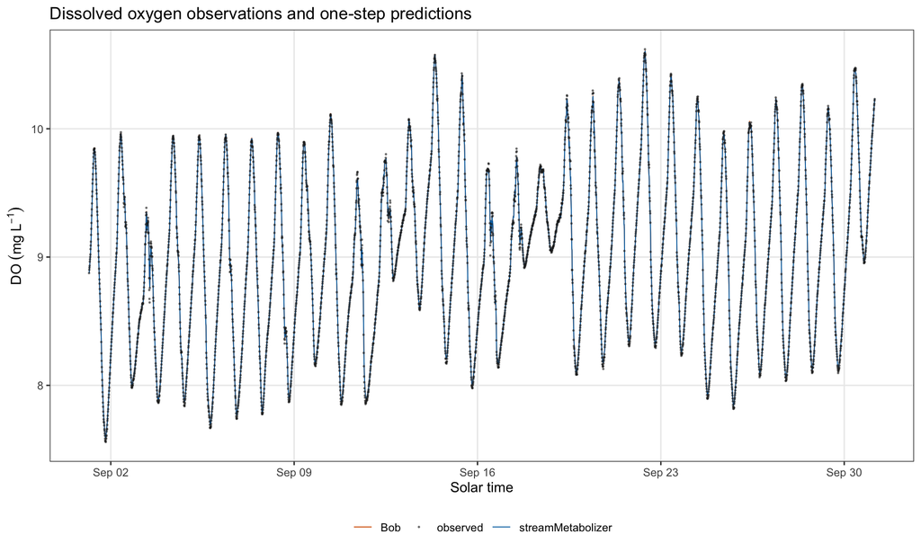

Figure 1: Dissolved oxygen observations and one-step predictions.

```r
plot_do_predictions <- ggplot2::ggplot(
  do_plot_data,
  ggplot2::aes(x = solar.time, y = DO, color = model)
) +
  ggplot2::geom_line(
    data = do_plot_data[do_plot_data$model != "observed", ],
    linewidth = 0.35
  ) +
  ggplot2::geom_point(
    data = do_plot_data[do_plot_data$model == "observed", ],
    size = 0.25,
    alpha = 0.5
  ) +
  ggplot2::scale_color_manual(values = model_colors) +
  ggplot2::labs(
    title = "Dissolved oxygen observations and one-step predictions",
    x = "Solar time",
    y = expression(DO ~ (mg ~ L^{-1})),
    color = NULL
  ) +
  plot_theme
plot_do_predictions
```

Daily metabolism estimates — the analog of `plot_metab_preds(predict_metab(sm_fit))`.

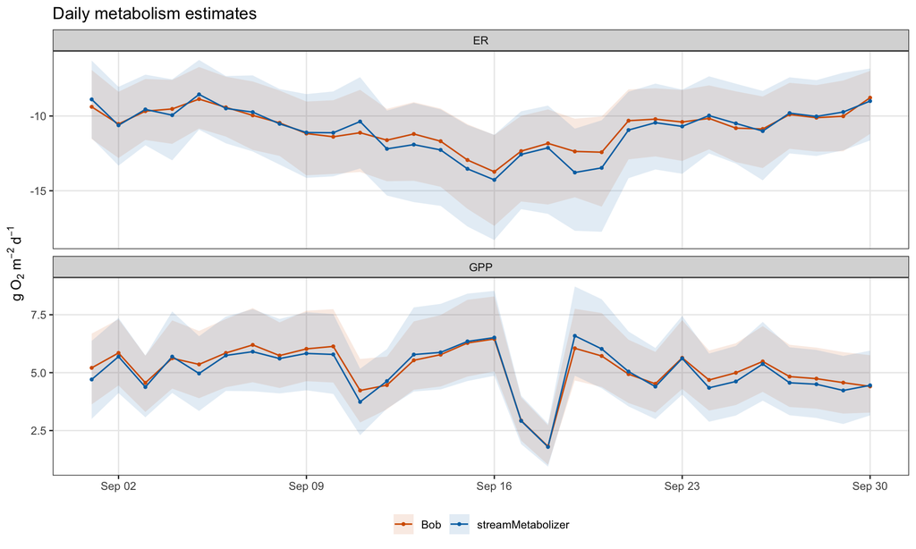

Figure 2: Daily metabolism estimates (GPP and ER) with 95% intervals.

```r
metab_plot_data <- rbind(
  data.frame(
    date = daily_comparison$date,
    parameter = daily_comparison$parameter,
    model = "Bob",
    estimate = daily_comparison$bob_median,
    lower = daily_comparison$bob_lower,
    upper = daily_comparison$bob_upper
  ),
  data.frame(
    date = daily_comparison$date,
    parameter = daily_comparison$parameter,
    model = "streamMetabolizer",
    estimate = daily_comparison$sm_median,
    lower = daily_comparison$sm_lower,
    upper = daily_comparison$sm_upper
  )
)
metab_plot_data <- metab_plot_data[
  metab_plot_data$parameter %in% c("GPP", "ER"),
]

plot_metabolism_predictions <- ggplot2::ggplot(
  metab_plot_data,
  ggplot2::aes(
    x = date,
    y = estimate,
    ymin = lower,
    ymax = upper,
    color = model,
    fill = model
  )
) +
  ggplot2::geom_ribbon(alpha = 0.12, color = NA) +
  ggplot2::geom_line(linewidth = 0.55) +
  ggplot2::geom_point(size = 0.8) +
  ggplot2::facet_wrap(~parameter, ncol = 1, scales = "free_y") +
  ggplot2::scale_color_manual(values = model_colors) +
  ggplot2::scale_fill_manual(values = model_colors) +
  ggplot2::labs(
    title = "Daily metabolism estimates",
    x = NULL,
    y = expression(g ~ O[2] ~ m^{-2} ~ d^{-1}),
    color = NULL,
    fill = NULL
  ) +
  plot_theme
plot_metabolism_predictions
```

streamMetabolizer daily GPP versus ER, and K600 versus ER for both models — analogs of `plot(params$GPP.daily, params$ER.daily)`, `plot(params$K600.daily, params$ER.daily)`, and `plot(K_est[,1], er_est[,1])`.

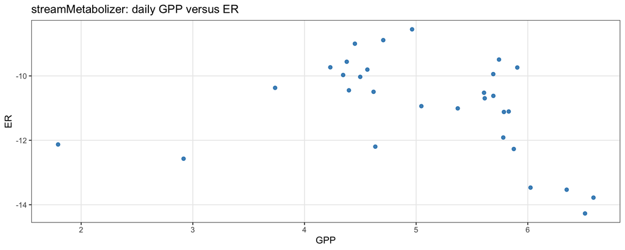

Figure 3: streamMetabolizer GPP vs. ER, and K600 vs. ER for each model.

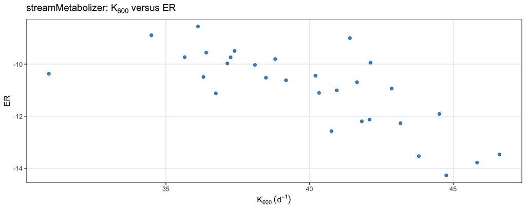

Figure 4: streamMetabolizer GPP vs. ER, and K600 vs. ER for each model.

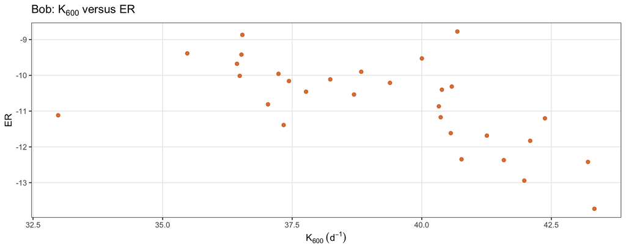

Figure 5: streamMetabolizer GPP vs. ER, and K600 vs. ER for each model.

```r
plot_stream_gpp_er <- model_scatter_plot(
  daily_wide,
  "streamMetabolizer",
  "sm_GPP",
  "sm_ER",
  "GPP",
  "ER",
  "streamMetabolizer: daily GPP versus ER"
)
plot_stream_k_er <- model_scatter_plot(
  daily_wide,
  "streamMetabolizer",
  "sm_K600",
  "sm_ER",
  expression(K[600] ~ (d^{-1})),
  "ER",
  expression(paste("streamMetabolizer: ", K[600], " versus ER"))
)
plot_bob_k_er <- model_scatter_plot(
  daily_wide,
  "Bob",
  "bob_K600",
  "bob_ER",
  expression(K[600] ~ (d^{-1})),
  "ER",
  expression(paste("Bob: ", K[600], " versus ER"))
)
plot_stream_gpp_er
plot_stream_k_er
plot_bob_k_er
```

Direct model-versus-model comparisons of daily GPP, K600, and ER.

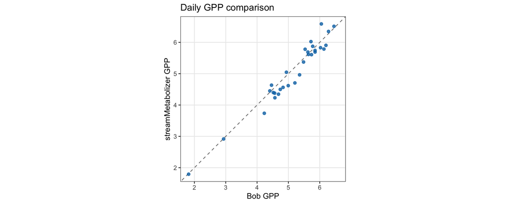

Figure 6: Daily GPP, K600, and ER: Bob vs. streamMetabolizer (dashed 1:1 line).

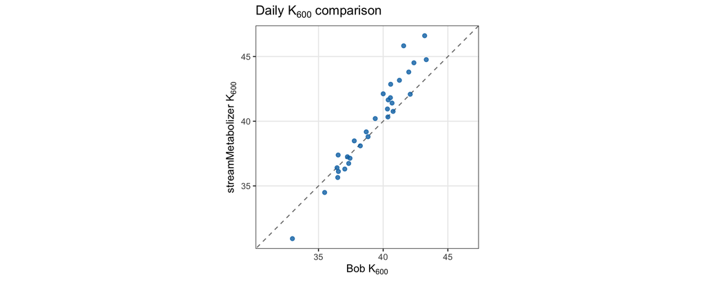

Figure 7: Daily GPP, K600, and ER: Bob vs. streamMetabolizer (dashed 1:1 line).

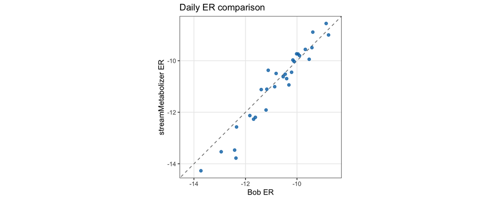

Figure 8: Daily GPP, K600, and ER: Bob vs. streamMetabolizer (dashed 1:1 line).

```r
plot_gpp_comparison <- parameter_comparison_plot(
  daily_comparison,
  "GPP",
  "Bob GPP",
  "streamMetabolizer GPP",
  "Daily GPP comparison"
)
plot_k_comparison <- parameter_comparison_plot(
  daily_comparison,
  "K600",
  expression(paste("Bob ", K[600])),
  expression(paste("streamMetabolizer ", K[600])),
  expression(paste("Daily ", K[600], " comparison"))
)
plot_er_comparison <- parameter_comparison_plot(
  daily_comparison,
  "ER",
  "Bob ER",
  "streamMetabolizer ER",
  "Daily ER comparison"
)
plot_gpp_comparison
plot_k_comparison
plot_er_comparison
```

Within-day process residuals: the two models’ residuals against each other, the first three days of one-step predictions, and the residual autocorrelation functions.

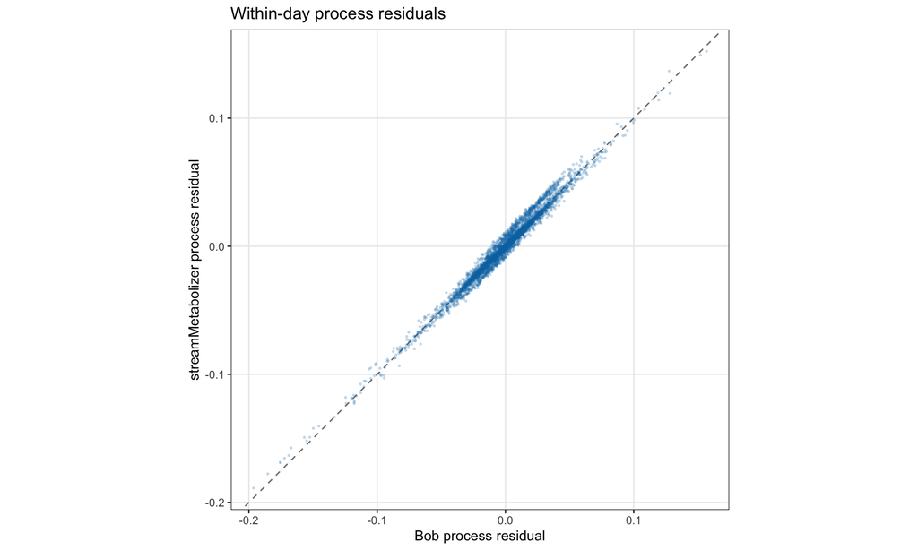

Figure 9: Within-day process residuals, first-three-days predictions, and residual ACF.

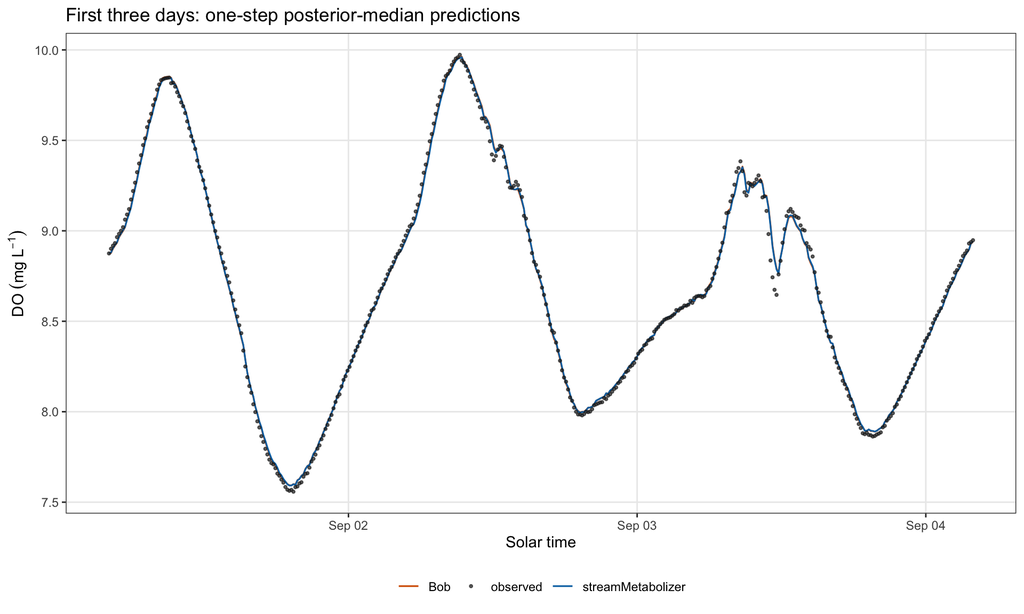

Figure 10: Within-day process residuals, first-three-days predictions, and residual ACF.

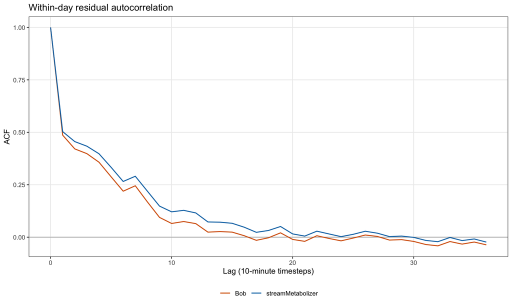

Figure 11: Within-day process residuals, first-three-days predictions, and residual ACF.

```r
plot_residual_comparison <- ggplot2::ggplot(
  residual_comparison,
  ggplot2::aes(x = bob_eta, y = sm_eta)
) +
  ggplot2::geom_abline(slope = 1, intercept = 0, linetype = 2, color = "grey50") +
  ggplot2::geom_point(
    alpha = 0.18,
    size = 0.45,
    color = model_colors[["streamMetabolizer"]]
  ) +
  ggplot2::coord_equal() +
  ggplot2::labs(
    title = "Within-day process residuals",
    x = "Bob process residual",
    y = "streamMetabolizer process residual"
  ) +
  plot_theme

show_rows <- seq_len(3 * ntime)
plot_first_three_days <- ggplot2::ggplot(
  do_plot_data[do_plot_data$solar.time %in% gallatin$solar.time[show_rows], ],
  ggplot2::aes(x = solar.time, y = DO, color = model)
) +
  ggplot2::geom_line(
    data = do_plot_data[
      do_plot_data$solar.time %in%
        gallatin$solar.time[show_rows] &
        do_plot_data$model != "observed",
    ],
    linewidth = 0.55
  ) +
  ggplot2::geom_point(
    data = do_plot_data[
      do_plot_data$solar.time %in%
        gallatin$solar.time[show_rows] &
        do_plot_data$model == "observed",
    ],
    size = 0.7,
    alpha = 0.7
  ) +
  ggplot2::scale_color_manual(values = model_colors) +
  ggplot2::labs(
    title = "First three days: one-step posterior-median predictions",
    x = "Solar time",
    y = expression(DO ~ (mg ~ L^{-1})),
    color = NULL
  ) +
  plot_theme

bob_acf <- stats::acf(as.vector(bob_eta), plot = FALSE)
sm_acf <- stats::acf(as.vector(sm_eta), plot = FALSE)
acf_data <- rbind(
  data.frame(
    lag = as.vector(bob_acf$lag),
    acf = as.vector(bob_acf$acf),
    model = "Bob"
  ),
  data.frame(
    lag = as.vector(sm_acf$lag),
    acf = as.vector(sm_acf$acf),
    model = "streamMetabolizer"
  )
)
plot_residual_acf <- ggplot2::ggplot(
  acf_data,
  ggplot2::aes(x = lag, y = acf, color = model)
) +
  ggplot2::geom_hline(yintercept = 0, color = "grey70") +
  ggplot2::geom_line(linewidth = 0.65) +
  ggplot2::scale_color_manual(values = model_colors) +
  ggplot2::labs(
    title = "Within-day residual autocorrelation",
    x = "Lag (10-minute timesteps)",
    y = "ACF",
    color = NULL
  ) +
  plot_theme

plot_residual_comparison
plot_first_three_days
plot_residual_acf
```

### IID process-error model figures

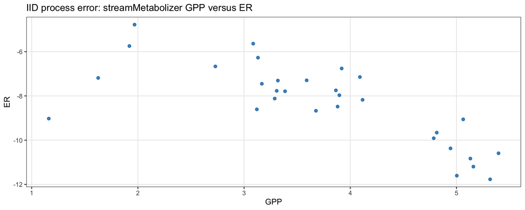

Figure 12: IID process error: GPP vs. ER and K600 vs. ER.

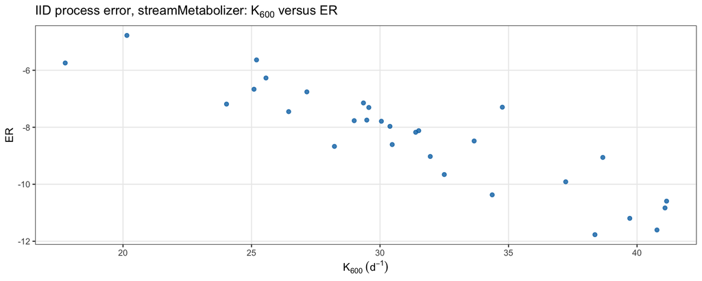

Figure 13: IID process error: GPP vs. ER and K600 vs. ER.

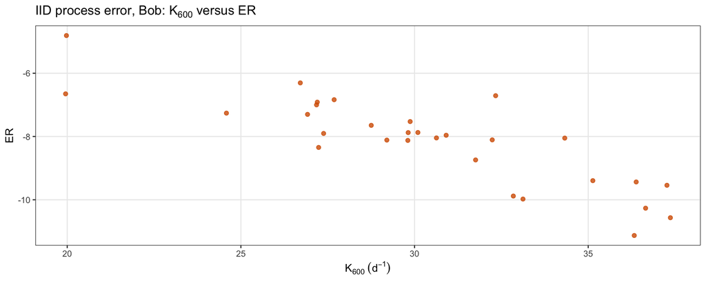

Figure 14: IID process error: GPP vs. ER and K600 vs. ER.

```r
plot_proc_stream_gpp_er <- model_scatter_plot(
  proc_daily_wide,
  "streamMetabolizer",
  "sm_GPP",
  "sm_ER",
  "GPP",
  "ER",
  "IID process error: streamMetabolizer GPP versus ER"
)
plot_proc_stream_k_er <- model_scatter_plot(
  proc_daily_wide,
  "streamMetabolizer",
  "sm_K600",
  "sm_ER",
  expression(K[600] ~ (d^{-1})),
  "ER",
  expression(paste("IID process error, streamMetabolizer: ", K[600], " versus ER"))
)
plot_proc_bob_k_er <- model_scatter_plot(
  proc_daily_wide,
  "Bob",
  "bob_K600",
  "bob_ER",
  expression(K[600] ~ (d^{-1})),
  "ER",
  expression(paste("IID process error, Bob: ", K[600], " versus ER"))
)
plot_proc_stream_gpp_er
plot_proc_stream_k_er
plot_proc_bob_k_er
```

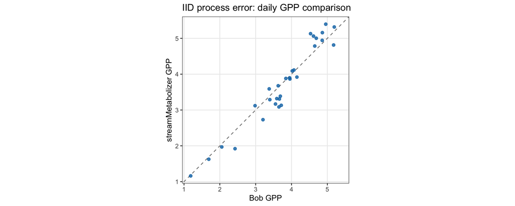

Figure 15: IID process error: daily GPP and K600, Bob vs. streamMetabolizer.

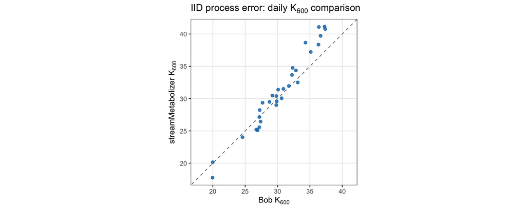

Figure 16: IID process error: daily GPP and K600, Bob vs. streamMetabolizer.

```r
plot_proc_gpp_comparison <- parameter_comparison_plot(
  proc_daily_comparison,
  "GPP",
  "Bob GPP",
  "streamMetabolizer GPP",
  "IID process error: daily GPP comparison"
)
plot_proc_k_comparison <- parameter_comparison_plot(
  proc_daily_comparison,
  "K600",
  expression(paste("Bob ", K[600])),
  expression(paste("streamMetabolizer ", K[600])),
  expression(paste("IID process error: daily ", K[600], " comparison"))
)
plot_proc_gpp_comparison
plot_proc_k_comparison
```

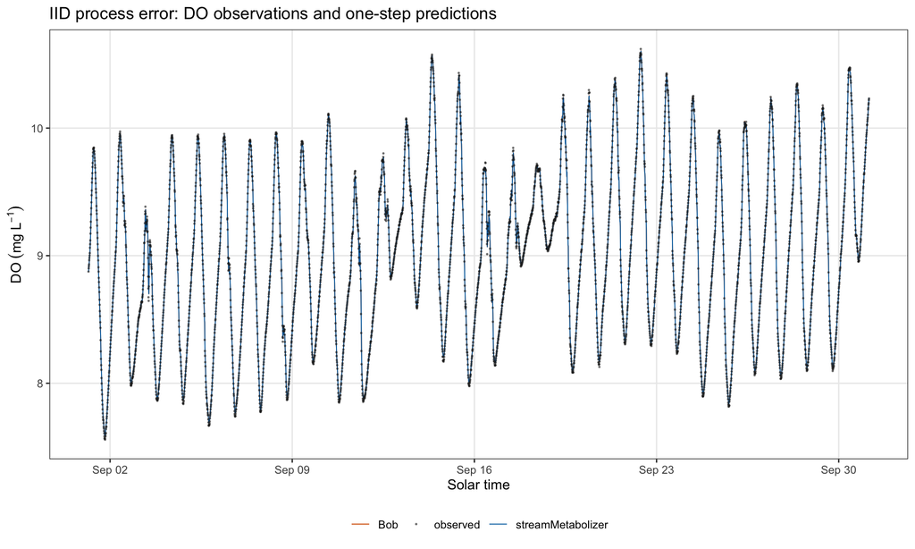

Figure 17: IID process error: DO predictions and within-day residuals.

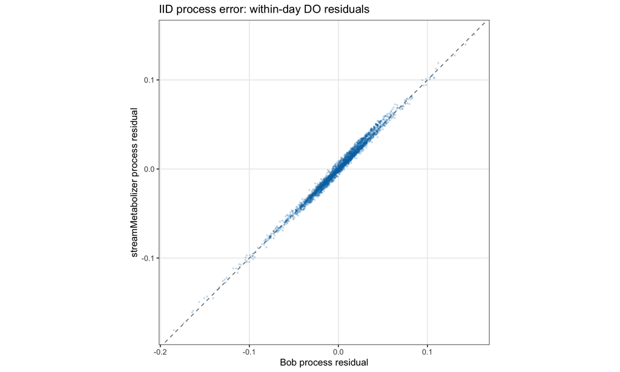

Figure 18: IID process error: DO predictions and within-day residuals.

```r
plot_proc_do_predictions <- ggplot2::ggplot(
  proc_do_plot_data,
  ggplot2::aes(x = solar.time, y = DO, color = model)
) +
  ggplot2::geom_line(
    data = proc_do_plot_data[proc_do_plot_data$model != "observed", ],
    linewidth = 0.35
  ) +
  ggplot2::geom_point(
    data = proc_do_plot_data[proc_do_plot_data$model == "observed", ],
    size = 0.25,
    alpha = 0.5
  ) +
  ggplot2::scale_color_manual(values = model_colors) +
  ggplot2::labs(
    title = "IID process error: DO observations and one-step predictions",
    x = "Solar time",
    y = expression(DO ~ (mg ~ L^{-1})),
    color = NULL
  ) +
  plot_theme

plot_proc_residual_comparison <- ggplot2::ggplot(
  proc_residual_comparison,
  ggplot2::aes(x = bob_eta, y = sm_eta)
) +
  ggplot2::geom_abline(slope = 1, intercept = 0, linetype = 2, color = "grey50") +
  ggplot2::geom_point(
    alpha = 0.18,
    size = 0.45,
    color = model_colors[["streamMetabolizer"]]
  ) +
  ggplot2::coord_equal() +
  ggplot2::labs(
    title = "IID process error: within-day DO residuals",
    x = "Bob process residual",
    y = "streamMetabolizer process residual"
  ) +
  plot_theme

plot_proc_do_predictions
plot_proc_residual_comparison
```

## Data checks

Confirm the data window and that Bob’s `KO2` conversion matches streamMetabolizer’s `convert_k600_to_kGAS()`.

```r
kc_stream <- convert_k600_to_kGAS(
  k600 = 1,
  temperature = gallatin$temp,
  gas = "O2"
)
data_checks <- data.frame(
  rows = nrow(gallatin),
  days = nday,
  observations_per_day = ntime,
  timestep_days = timestep_days,
  max_abs_KO2_conversion_difference = max(
    abs(gallatin$Kc_bob - kc_stream),
    na.rm = TRUE
  )
)
write_output_csv(data_checks, "data_checks.csv")
knitr::kable(data_checks)
```

| rows | days | observations_per_day | timestep_days | max_abs_KO2_conversion_difference |
| --- | --- | --- | --- | --- |
| 4320 | 30 | 144 | 0.0069444 | 0.0329007 |

## Comparison notes

Key details that matter when reading the comparison above.

- **Bob Stan file:** /Users/connor/GitHub/metab_proc_err/metab_pi_ar_light_2_modern.stan
- **streamMetabolizer model:** b_Kn_pclv_eu_plrcko.stan
- **Bob IID process-error Stan file:** /Users/connor/GitHub/metab_proc_err/metab_pi_2_modern.stan
- **streamMetabolizer IID process-error model:** b_Kn_pi_eu_plrcko.stan
- **Sampling:** chains = 4, iter = 2000, warmup = 1000

## Save artifacts

When `write_outputs` is `TRUE`, also write the figures to PNG and a combined PDF into the output directory, reproducing the file layout of the original script. When `save_fits` is `TRUE`, the fitted objects are saved as `.rds`.

```r
comparison_plots <- list(
  "01_do_predictions" = plot_do_predictions,
  "02_metabolism_predictions" = plot_metabolism_predictions,
  "03_stream_gpp_vs_er" = plot_stream_gpp_er,
  "04_stream_k600_vs_er" = plot_stream_k_er,
  "05_bob_k600_vs_er" = plot_bob_k_er,
  "06_gpp_model_comparison" = plot_gpp_comparison,
  "07_k600_model_comparison" = plot_k_comparison,
  "08_er_model_comparison" = plot_er_comparison,
  "09_residual_comparison" = plot_residual_comparison,
  "10_first_three_days" = plot_first_three_days,
  "11_residual_acf" = plot_residual_acf,
  "12_proc_stream_gpp_vs_er" = plot_proc_stream_gpp_er,
  "13_proc_stream_k600_vs_er" = plot_proc_stream_k_er,
  "14_proc_bob_k600_vs_er" = plot_proc_bob_k_er,
  "15_proc_gpp_model_comparison" = plot_proc_gpp_comparison,
  "16_proc_k600_model_comparison" = plot_proc_k_comparison,
  "17_proc_do_predictions" = plot_proc_do_predictions,
  "18_proc_residual_comparison" = plot_proc_residual_comparison
)

if (params$write_outputs) {
  for (plot_name in names(comparison_plots)) {
    ggplot2::ggsave(
      filename = file.path(output_dir, paste0(plot_name, ".png")),
      plot = comparison_plots[[plot_name]],
      width = 10,
      height = 6,
      dpi = 300
    )
  }
  grDevices::pdf(
    file.path(output_dir, "comparison_plots.pdf"),
    width = 10,
    height = 6,
    onefile = TRUE
  )
  invisible(lapply(comparison_plots, print))
  grDevices::dev.off()
}
```

```r
if (save_fits) {
  saveRDS(bob_fit, file.path(output_dir, "bob_fit.rds"), compress = FALSE)
  saveRDS(
    sm_fit,
    file.path(output_dir, "streamMetabolizer_fit.rds"),
    compress = FALSE
  )
  saveRDS(
    bob_proc_fit,
    file.path(output_dir, "bob_proc_fit.rds"),
    compress = FALSE
  )
  saveRDS(
    sm_proc_fit,
    file.path(output_dir, "streamMetabolizer_proc_fit.rds"),
    compress = FALSE
  )
}

if (params$write_outputs) {
  message("Artifacts written to: ", normalizePath(output_dir))
}
```